# Practical Machine Learning - Prediction Assigment

HJL

21 elokuuta 2016

[output not shown]

## Study the data

After downloading and reading the data from the source I’ll do some data study.

```r
dim(Training_ORG)
```

```
## [1] 19622   160
```

```r
dim(Testing_ORG)
```

```
## [1]  20 160
```

**Remarks**

- The training data set consists of 19622 observations and 160 variables.
- The testing data set consists s 20 observations and 160 variables.
- The “classe” variable in the training set is the outcome to predict.

## Cleaning data

This step removes NA missing values.

```r
Training_ORG <- Training_ORG[, colSums(is.na(Training_ORG)) == 0]
Testing_ORG <- Testing_ORG[, colSums(is.na(Testing_ORG)) == 0]
```

After removing NA’s, I’ll remove all columns which doesen’t contribute much to the measurements.

```r
classe <- Training_ORG$classe
Training_RM <- grepl("^X|timestamp|window", names(Training_ORG))
Training_ORG <- Training_ORG[, !Training_RM]
Trainning_Fixed <- Training_ORG[, sapply(Training_ORG, is.numeric)]
Trainning_Fixed$classe <- classe

Testing_RM <- grepl("^X|timestamp|window", names(Testing_ORG))
Testing_ORG <- Testing_ORG[, !Testing_RM]
Testing_Fixed <- Testing_ORG[, sapply(Testing_ORG, is.numeric)]
```

## Study the data after cleaning

```r
dim(Trainning_Fixed)
```

```
## [1] 19622    53
```

```r
dim(Testing_Fixed)
```

```
## [1] 20 53
```

**Remarks**

- The fixed training data set consists of 19622 observations and 53 variables.
- The fixed testing data set consists s 20 observations and 53 variables.

## Divide the training data

I’ll Divide the training data set into two. One for training (TrainSet) and one for validating (TestSet).

- 70% for training
- 30% for validating

```r
set.seed(11451)
inTrain <- createDataPartition(Trainning_Fixed$classe, p=0.70, list=F)
TrainSet <- Trainning_Fixed[inTrain, ]
TestSet <- Trainning_Fixed[-inTrain, ]
```

### Correlation Matrix

Study the TrainSet

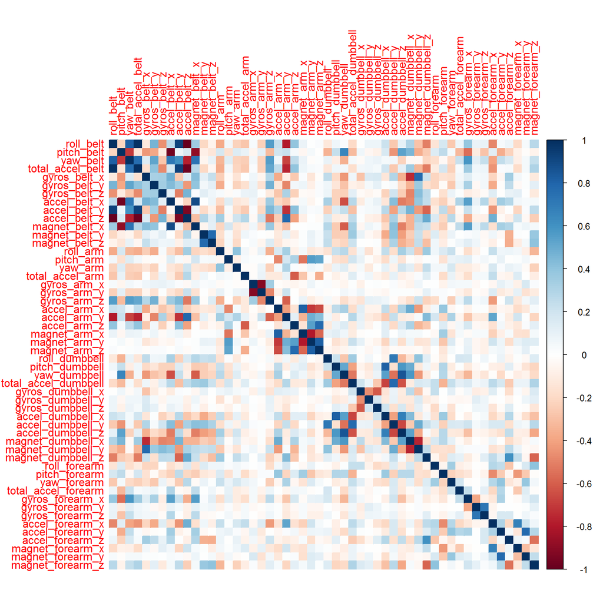

```r
corrPlot <- cor(TrainSet[, -length(names(TrainSet))])
corrplot(corrPlot, method="color")
```

### Decision Tree

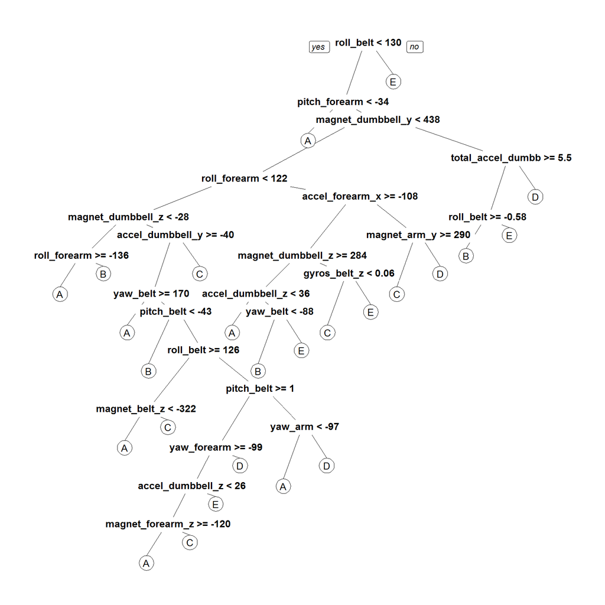

```r
treeModel <- rpart(classe ~ ., data=TrainSet, method="class")
prp(treeModel)
```

## Modeling

Random Forest algorithm fits best to this prediction because it automatically selects all important variables.

```r
control <- trainControl(method="cv", 5)
model <- train(classe ~ ., data=TrainSet, method="rf", trControl=control, ntree=250)
print(model)
```

```
## Random Forest
##
## 13737 samples
##    52 predictor
##     5 classes: 'A', 'B', 'C', 'D', 'E'
##
## No pre-processing
## Resampling: Cross-Validated (5 fold)
## Summary of sample sizes: 10991, 10989, 10990, 10989, 10989
## Resampling results across tuning parameters:
##
##   mtry  Accuracy   Kappa
##    2    0.9917014  0.9895017
##   27    0.9913373  0.9890416
##   52    0.9845670  0.9804755
##
## Accuracy was used to select the optimal model using  the largest value.
## The final value used for the model was mtry = 2.
```

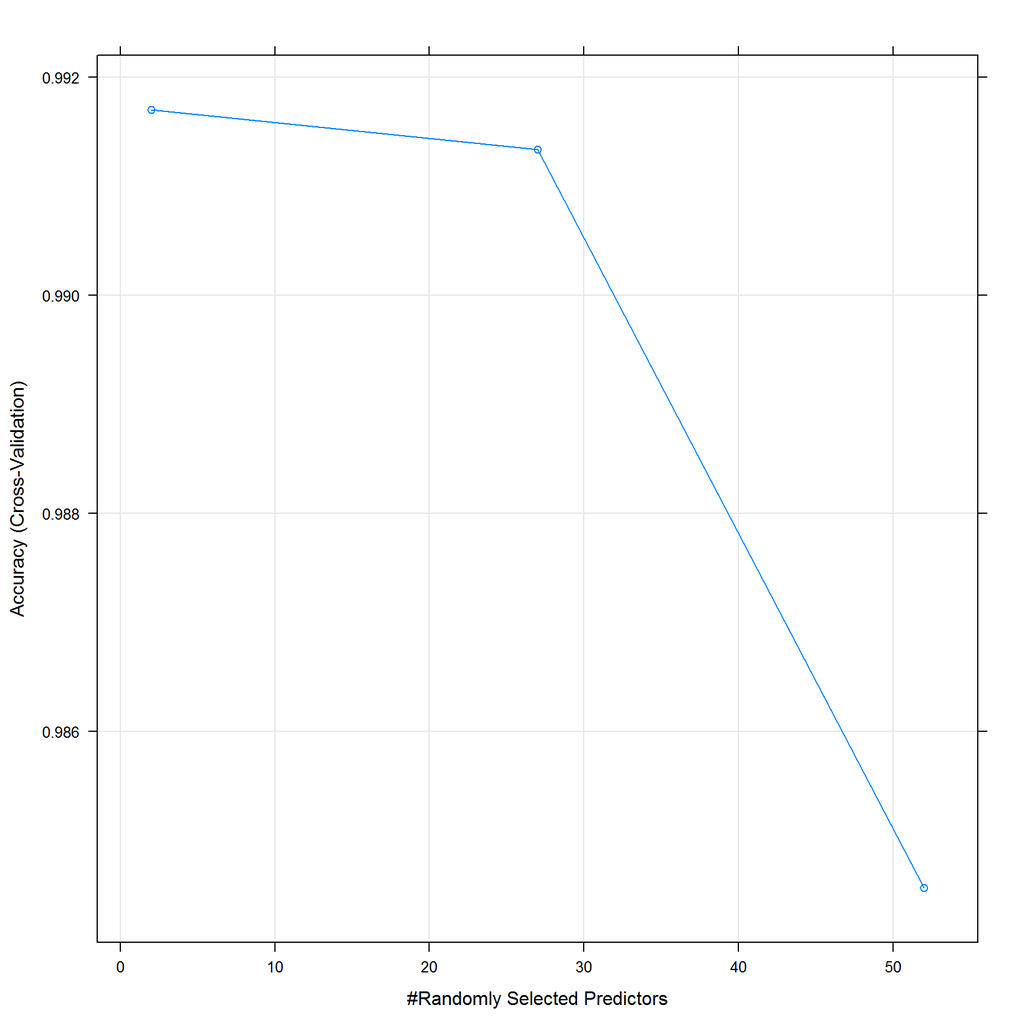

```r
plot(model)
```

Check how the model perform with the TestSet (validation)

```r
PredictRF <- predict(model,TestSet)
confusionMatrix(TestSet$classe, PredictRF)
```

```
## Confusion Matrix and Statistics
##
##           Reference
## Prediction    A    B    C    D    E
##          A 1674    0    0    0    0
##          B    0 1138    1    0    0
##          C    0    2 1024    0    0
##          D    0    0    3  960    1
##          E    0    0    0    0 1082
##
## Overall Statistics
##
##                Accuracy : 0.9988
##                  95% CI : (0.9976, 0.9995)
##     No Information Rate : 0.2845
##     P-Value [Acc > NIR] : < 2.2e-16
##
##                   Kappa : 0.9985
##  Mcnemar's Test P-Value : NA
##
## Statistics by Class:
##
##                      Class: A Class: B Class: C Class: D Class: E
## Sensitivity            1.0000   0.9982   0.9961   1.0000   0.9991
## Specificity            1.0000   0.9998   0.9996   0.9992   1.0000
## Pos Pred Value         1.0000   0.9991   0.9981   0.9959   1.0000
## Neg Pred Value         1.0000   0.9996   0.9992   1.0000   0.9998
## Prevalence             0.2845   0.1937   0.1747   0.1631   0.1840
## Detection Rate         0.2845   0.1934   0.1740   0.1631   0.1839
## Detection Prevalence   0.2845   0.1935   0.1743   0.1638   0.1839
## Balanced Accuracy      1.0000   0.9990   0.9978   0.9996   0.9995
```

```r
accuracy <- postResample(PredictRF, TestSet$classe)
print(accuracy)
```

```
##  Accuracy     Kappa
## 0.9988105 0.9984955
```

```r
OutOfSampleERR <- 1 - as.numeric(confusionMatrix(TestSet$classe, PredictRF)$overall[1])
print(OutOfSampleERR)
```

```
## [1] 0.001189465
```

**Estimate for**

- Accuracy for the model is 99.88%
- out-of-sample error is 0.12%

## Test Data Set, prediction

I’ll use created model to the cleaned original test data set.

```r
StudyResult <- predict(model, Testing_Fixed[, -length(names(Testing_Fixed))])
print(StudyResult)
```

```
##  [1] B A B A A E D B A A B C B A E E A B B B
## Levels: A B C D E
```

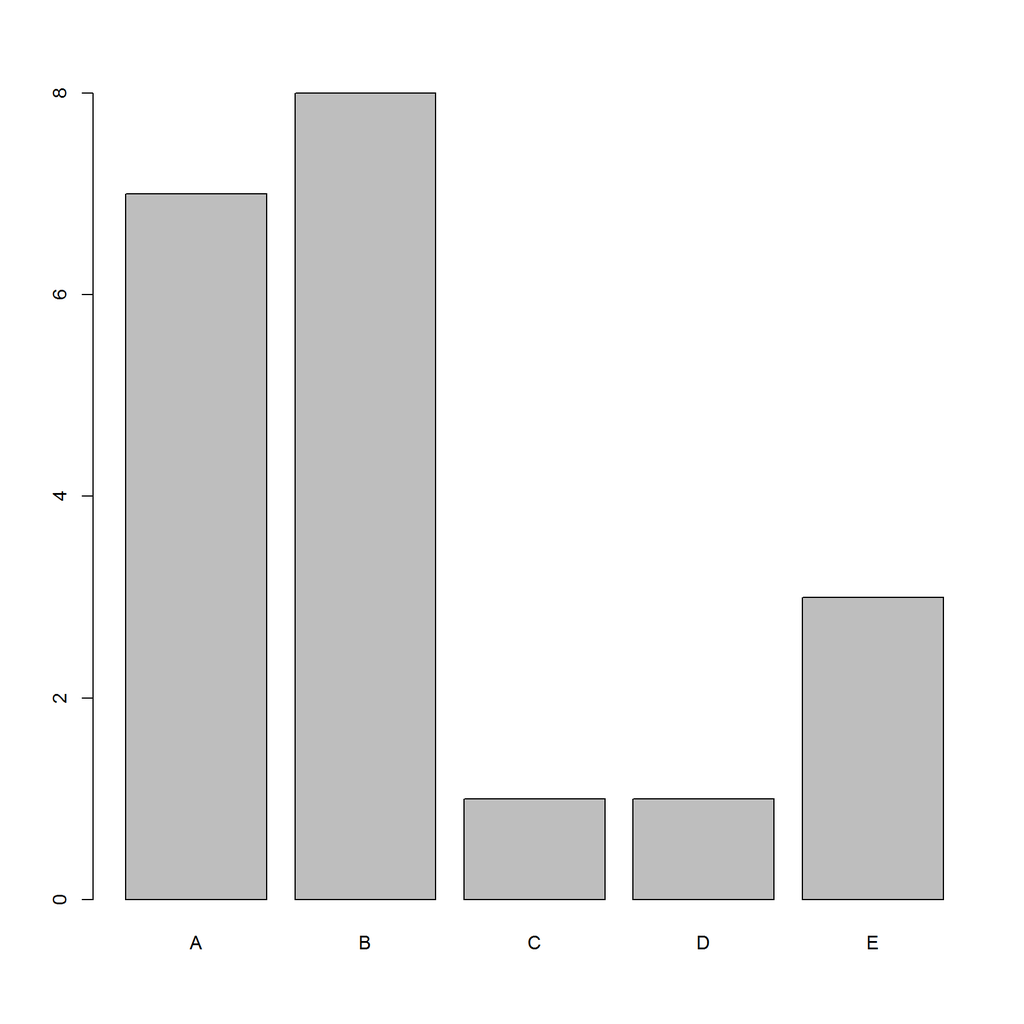

```r
plot(StudyResult)
```